# CLT Simulation App

May 9, 2018

## Central Limit Theorem

The Central Limit Theorem is the first highly nontrivial theorem that many students learning statistics encounter, with incredibly important corrolaries.

As such, it is important that students cultivate a deep intuition for how the theorem works. To this end, we have developed a simple app which allows users to simulate this convergence. Students can select one of three common distributions and observe how sample means from these distributions converge to an appropriately scaled normal distribution.

## Pedagogical Goals

We have singled out the following as essential aspects of a complete "understanding" of the Central Limit Theorem, and have designed the app to highlight them:

- Understanding convergence in distribution/pointwise convergence
- Understanding the construction of confidence intervals.
- Understanding how different distributions converge at different rates

## Convergence in distribution

To show convergence in distribution, we have overlaid in the visualization of the appropriate limiting curve over the experimental density of sample averages.

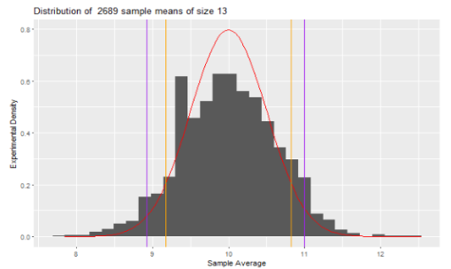

The inclusion of confidence intervals (as predicted by CLT vs/empirical confidence intervals) allows students to appreciate slow convergence at the tails.

## Different distributions, different rates

Upon selecting a given distribution, students have slider options to change the parameters of the distribution (e.g. the rate parameter for the exponential distribution). Observation of how different values for population parameters influences convergence could lead into a discussion on what quantities (higher moments) govern rate of convergence.